# examen_parte_1

Natalia Gavaldá

2025-01-17

## Datos, librerías y directorio

```r
library(ggplot2)

setwd("/Users/jjmilla/Repositorios/master-umh-stat/master-umh-stat/Visualización datos/datos")

spain=read.csv("spain.csv")
world=read.csv("world2007.csv")
```

## Ejercicio 1

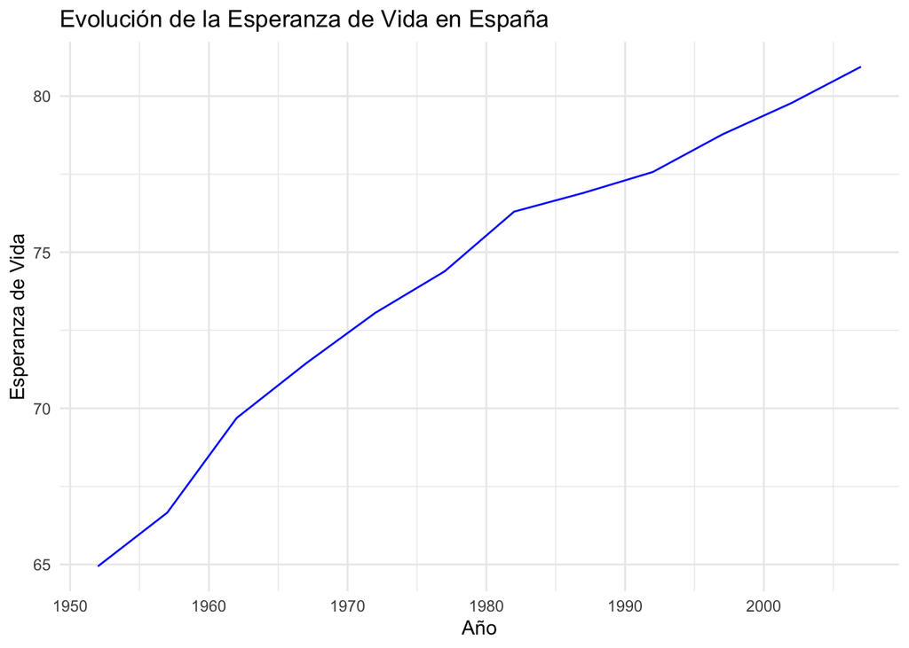

```r
ggplot(spain, aes(x = year, y = lifeExp)) +
  geom_line(color = "blue") +
  labs(title = "Evolución de la Esperanza de Vida en España",
       x = "Año",
       y = "Esperanza de Vida") +
  theme_minimal()
```

## Ejercicio 2

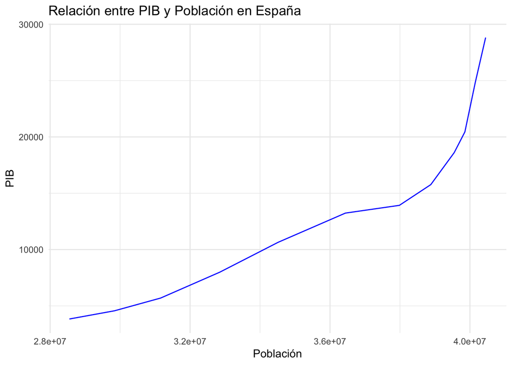

```r
ggplot(spain, aes(x = pop, y = gdp)) +
  geom_line(color = "blue") +
  labs(title = "Relación entre PIB y Población en España",
       x = "Población",
       y = "PIB") +
  theme_minimal()
```

**Conclusiones**

- A medida que la población ha ido aumentando también lo ha hecho el PIP.
- Ahora mismo nos encontramos en un máximo de población y PIB según el histórico del que dispononemos.
- Aunque la relación no es completamente lineal, se puede observar que a mayor población mayor PIB.

## Ejercicio 3

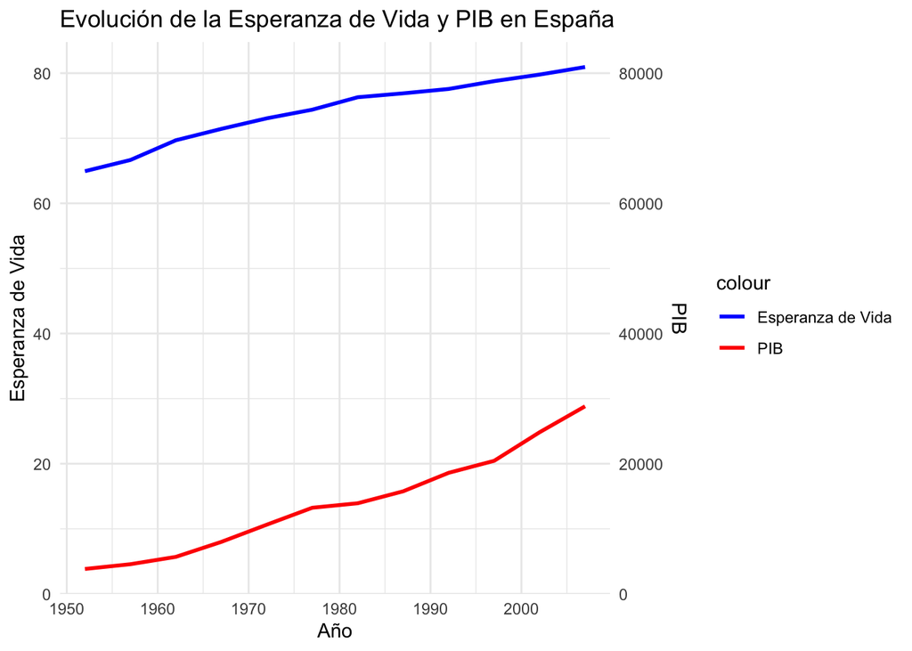

```r
ggplot(spain, aes(x = year)) +
  geom_line(aes(y = lifeExp, color = "Esperanza de Vida"), linewidth = 1) +
  geom_line(aes(y = gdp / 1000, color = "PIB"), linewidth = 1) +
  scale_y_continuous(
    name = "Esperanza de Vida",
    sec.axis = sec_axis(~.*1000, name = "PIB")
  ) +
  labs(title = "Evolución de la Esperanza de Vida y PIB en España",
       x = "Año") +
  scale_color_manual(values = c("blue", "red")) +
  theme_minimal()
```

- La tendencia de la esperanza de vida es creciente así como la del PIB.

## Ejercicio 4

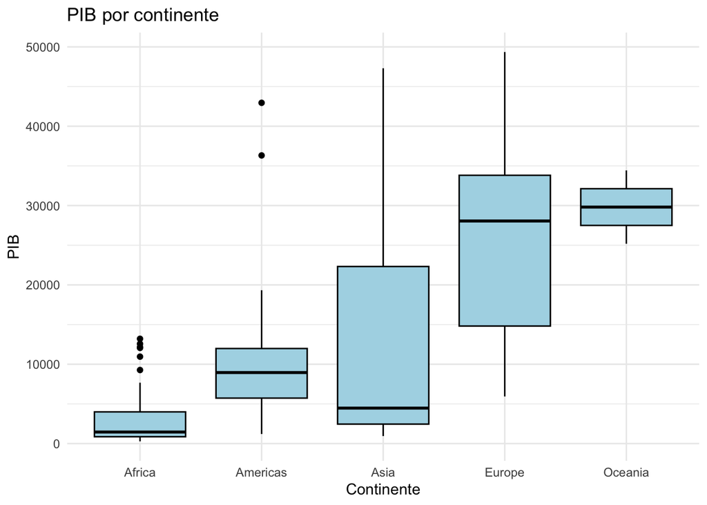

```r
ggplot(world, aes(x = continent, y = gdp)) +
  geom_boxplot(fill = "lightblue", color = "black") +
  labs(title = "PIB por continente",
       x = "Continente",
       y = "PIB") +
  theme_minimal()
```

## Ejercicio 5

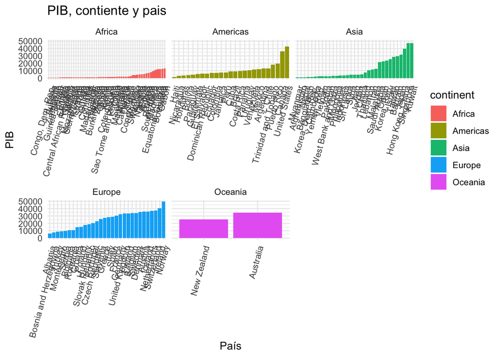

```r
ggplot(world, aes(x = reorder(country, gdp), y = gdp, fill = continent)) +
  geom_bar(stat = "identity") +
  facet_wrap(~ continent, scales = "free_x") +
  labs(title = "PIB, contiente y pais",
       x = "País",
       y = "PIB") +
  theme_minimal() +
  theme(axis.text.x = element_text(angle = 75, hjust = 1))
```

- Con el grafico 5 se puede apreciar la distribución del propio continente viendo los totales por país como ventaja de uno sobre el otro. En cambio, con el gráfico 4 podemos ver los outliers mucho mejor que con el gráfico de barras por país.
- Conclusón final: Ambos gráficos son complementarios. En uno podemos ver el dato agregado por continente y en el otro desglosado por país. Dependiendo del objeto del análisis puede ser interesante uno u otro.

## Ejercicio 6

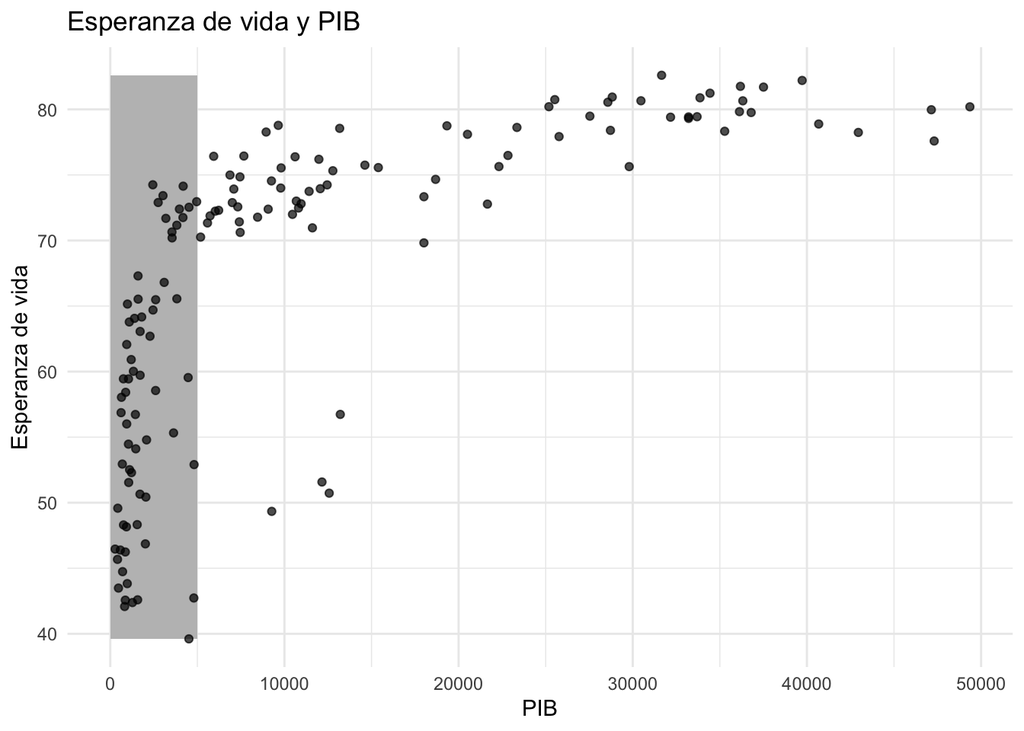

```r
# Crear el gráfico con un rectángulo desde 0 a 5000 en PIB
ggplot(world, aes(x = gdp, y = lifeExp)) +
  geom_rect(aes(xmin = 0, xmax = 5000, ymin = min(lifeExp), ymax = max(lifeExp)),
            fill = "gray", alpha = 0.2) +
  geom_point(alpha = 0.7) +
  labs(title = "Esperanza de vida y PIB",
       x = "PIB",
       y = "Esperanza de vida") +
  theme_minimal()
```

Se puede observar que a una menor esperanza de vida, el PIB es más bajo. A medida que la esperanza de vida aumenta, el PIB también lo hace. Aunque no es una relación lineal, se puede observar que a una esperanza de vida de más de 70 años, el PIB es mayor.

## Ejercicio 7

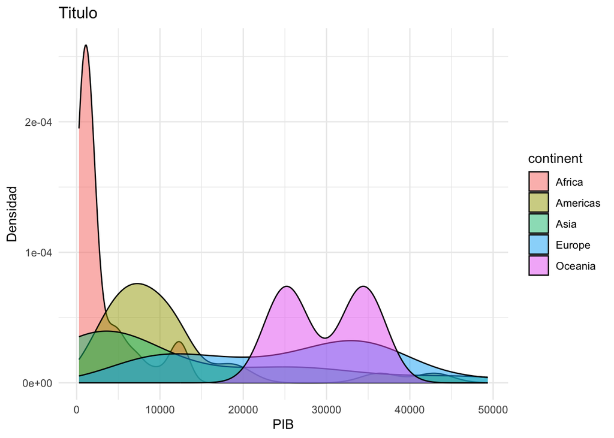

```r
ggplot(world, aes(x = gdp, fill = continent)) +
  geom_density(alpha = 0.5) +
  labs(title = "Titulo",
       x = "PIB",
       y = "Densidad") +
  theme_minimal()
```